# Risk Factor Analysis

## Outcome Variable

**Outcome Variable:** wast_rec90d

## Predictor Variables

**Intervention Variable:** hdlvry

**Adjustment Set:**

- arm
- sex
- W_mage
- meducyrs
- feducyrs
- hhwealth_quart
- single
- W_nrooms
- brthmon
- W_parity
- impsan
- delta_W_mage
- delta_meducyrs
- delta_feducyrs
- delta_hhwealth_quart
- delta_single
- delta_W_nrooms
- delta_brthmon
- delta_W_parity
- delta_impsan

## Stratifying Variables

The analysis was stratified on these variable(s):

- agecat
- studyid
- country

## Data Summary

| agecat | studyid | country | hdlvry | wast_rec90d | n_cell | n |
| --- | --- | --- | --- | --- | --- | --- |
| 0-24 months | ki1000108-CMC-V-BCS-2002 | INDIA | 0 | 0 | 115 | 320 |
| 0-24 months | ki1000108-CMC-V-BCS-2002 | INDIA | 0 | 1 | 199 | 320 |
| 0-24 months | ki1000108-CMC-V-BCS-2002 | INDIA | 1 | 0 | 4 | 320 |
| 0-24 months | ki1000108-CMC-V-BCS-2002 | INDIA | 1 | 1 | 2 | 320 |
| 0-24 months | ki1000108-IRC | INDIA | 0 | 0 | 159 | 395 |
| 0-24 months | ki1000108-IRC | INDIA | 0 | 1 | 227 | 395 |
| 0-24 months | ki1000108-IRC | INDIA | 1 | 0 | 3 | 395 |
| 0-24 months | ki1000108-IRC | INDIA | 1 | 1 | 6 | 395 |
| 0-24 months | ki1000109-EE | PAKISTAN | 0 | 0 | 106 | 322 |
| 0-24 months | ki1000109-EE | PAKISTAN | 0 | 1 | 107 | 322 |
| 0-24 months | ki1000109-EE | PAKISTAN | 1 | 0 | 53 | 322 |
| 0-24 months | ki1000109-EE | PAKISTAN | 1 | 1 | 56 | 322 |
| 0-24 months | ki1000304b-SAS-CompFeed | INDIA | 0 | 0 | 34 | 675 |
| 0-24 months | ki1000304b-SAS-CompFeed | INDIA | 0 | 1 | 30 | 675 |
| 0-24 months | ki1000304b-SAS-CompFeed | INDIA | 1 | 0 | 386 | 675 |
| 0-24 months | ki1000304b-SAS-CompFeed | INDIA | 1 | 1 | 225 | 675 |
| 0-24 months | ki1000304b-SAS-FoodSuppl | INDIA | 0 | 0 | 40 | 234 |
| 0-24 months | ki1000304b-SAS-FoodSuppl | INDIA | 0 | 1 | 0 | 234 |
| 0-24 months | ki1000304b-SAS-FoodSuppl | INDIA | 1 | 0 | 181 | 234 |
| 0-24 months | ki1000304b-SAS-FoodSuppl | INDIA | 1 | 1 | 13 | 234 |
| 0-24 months | ki1017093b-PROVIDE | BANGLADESH | 0 | 0 | 94 | 308 |
| 0-24 months | ki1017093b-PROVIDE | BANGLADESH | 0 | 1 | 132 | 308 |
| 0-24 months | ki1017093b-PROVIDE | BANGLADESH | 1 | 0 | 35 | 308 |
| 0-24 months | ki1017093b-PROVIDE | BANGLADESH | 1 | 1 | 47 | 308 |
| 0-24 months | ki1017093c-NIH-Crypto | BANGLADESH | 0 | 0 | 79 | 310 |
| 0-24 months | ki1017093c-NIH-Crypto | BANGLADESH | 0 | 1 | 139 | 310 |
| 0-24 months | ki1017093c-NIH-Crypto | BANGLADESH | 1 | 0 | 38 | 310 |
| 0-24 months | ki1017093c-NIH-Crypto | BANGLADESH | 1 | 1 | 54 | 310 |
| 0-24 months | ki1066203-TanzaniaChild2 | TANZANIA, UNITED REPUBLIC OF | 0 | 0 | 250 | 682 |
| 0-24 months | ki1066203-TanzaniaChild2 | TANZANIA, UNITED REPUBLIC OF | 0 | 1 | 423 | 682 |

[output cut: 114 more lines]

The following strata were considered:

- agecat: 0-24 months, studyid: ki1000108-CMC-V-BCS-2002, country: INDIA
- agecat: 0-24 months, studyid: ki1000108-IRC, country: INDIA
- agecat: 0-24 months, studyid: ki1000109-EE, country: PAKISTAN
- agecat: 0-24 months, studyid: ki1000304b-SAS-CompFeed, country: INDIA
- agecat: 0-24 months, studyid: ki1000304b-SAS-FoodSuppl, country: INDIA
- agecat: 0-24 months, studyid: ki1017093b-PROVIDE, country: BANGLADESH
- agecat: 0-24 months, studyid: ki1017093c-NIH-Crypto, country: BANGLADESH
- agecat: 0-24 months, studyid: ki1066203-TanzaniaChild2, country: TANZANIA, UNITED REPUBLIC OF
- agecat: 0-24 months, studyid: ki1113344-GMS-Nepal, country: NEPAL
- agecat: 0-24 months, studyid: ki1135781-COHORTS, country: INDIA
- agecat: 0-24 months, studyid: kiGH5241-JiVitA-3, country: BANGLADESH
- agecat: 0-24 months, studyid: kiGH5241-JiVitA-4, country: BANGLADESH
- agecat: 0-6 months, studyid: ki1000108-CMC-V-BCS-2002, country: INDIA
- agecat: 0-6 months, studyid: ki1000108-IRC, country: INDIA
- agecat: 0-6 months, studyid: ki1000109-EE, country: PAKISTAN
- agecat: 0-6 months, studyid: ki1000304b-SAS-CompFeed, country: INDIA
- agecat: 0-6 months, studyid: ki1000304b-SAS-FoodSuppl, country: INDIA
- agecat: 0-6 months, studyid: ki1017093b-PROVIDE, country: BANGLADESH
- agecat: 0-6 months, studyid: ki1017093c-NIH-Crypto, country: BANGLADESH
- agecat: 0-6 months, studyid: ki1066203-TanzaniaChild2, country: TANZANIA, UNITED REPUBLIC OF
- agecat: 0-6 months, studyid: ki1113344-GMS-Nepal, country: NEPAL
- agecat: 0-6 months, studyid: ki1135781-COHORTS, country: INDIA
- agecat: 0-6 months, studyid: kiGH5241-JiVitA-3, country: BANGLADESH
- agecat: 0-6 months, studyid: kiGH5241-JiVitA-4, country: BANGLADESH
- agecat: 6-24 months, studyid: ki1000108-CMC-V-BCS-2002, country: INDIA
- agecat: 6-24 months, studyid: ki1000108-IRC, country: INDIA
- agecat: 6-24 months, studyid: ki1000109-EE, country: PAKISTAN
- agecat: 6-24 months, studyid: ki1000304b-SAS-CompFeed, country: INDIA
- agecat: 6-24 months, studyid: ki1000304b-SAS-FoodSuppl, country: INDIA
- agecat: 6-24 months, studyid: ki1017093b-PROVIDE, country: BANGLADESH
- agecat: 6-24 months, studyid: ki1017093c-NIH-Crypto, country: BANGLADESH
- agecat: 6-24 months, studyid: ki1066203-TanzaniaChild2, country: TANZANIA, UNITED REPUBLIC OF
- agecat: 6-24 months, studyid: ki1113344-GMS-Nepal, country: NEPAL
- agecat: 6-24 months, studyid: ki1135781-COHORTS, country: INDIA
- agecat: 6-24 months, studyid: kiGH5241-JiVitA-3, country: BANGLADESH
- agecat: 6-24 months, studyid: kiGH5241-JiVitA-4, country: BANGLADESH

### Dropped Strata

Some strata were dropped due to rare outcomes:

- agecat: 0-24 months, studyid: ki1000108-CMC-V-BCS-2002, country: INDIA
- agecat: 0-24 months, studyid: ki1000108-IRC, country: INDIA
- agecat: 0-24 months, studyid: ki1000304b-SAS-FoodSuppl, country: INDIA
- agecat: 0-24 months, studyid: ki1066203-TanzaniaChild2, country: TANZANIA, UNITED REPUBLIC OF
- agecat: 0-6 months, studyid: ki1000108-CMC-V-BCS-2002, country: INDIA
- agecat: 0-6 months, studyid: ki1000108-IRC, country: INDIA
- agecat: 0-6 months, studyid: ki1000304b-SAS-FoodSuppl, country: INDIA
- agecat: 0-6 months, studyid: ki1066203-TanzaniaChild2, country: TANZANIA, UNITED REPUBLIC OF
- agecat: 0-6 months, studyid: kiGH5241-JiVitA-3, country: BANGLADESH
- agecat: 6-24 months, studyid: ki1000108-CMC-V-BCS-2002, country: INDIA
- agecat: 6-24 months, studyid: ki1000108-IRC, country: INDIA
- agecat: 6-24 months, studyid: ki1000304b-SAS-FoodSuppl, country: INDIA
- agecat: 6-24 months, studyid: ki1017093c-NIH-Crypto, country: BANGLADESH
- agecat: 6-24 months, studyid: ki1066203-TanzaniaChild2, country: TANZANIA, UNITED REPUBLIC OF
- agecat: 6-24 months, studyid: ki1135781-COHORTS, country: INDIA
- agecat: 6-24 months, studyid: kiGH5241-JiVitA-3, country: BANGLADESH

## Methods Detail

We’re interested in the causal parameters $E[Y_a]$ for all values of $a \in \mathcal{A}$. These parameters represent the mean outcome if, possibly contrary to fact, we intervened to set all units to have $A=a$. Under the randomization and positivity assumptions, these are identified by the statistical parameters $\psi_a=E_W[E_{Y|A,W}(Y|A=a,W)]$. In addition, we’re interested in the mean of $Y$, $E[Y]$ under no intervention (the observed mean). We will estimate these parameters by using SuperLearner to fit the relevant likelihood factors – $E_{Y|A,W}(Y|A=a,W)$ and $p(A=a|W)$, and then updating our likelihood fit using a joint TMLE.

For unadjusted analyses ($W=\{\}$), initial likelihoods were estimated using Lrnr_glm to estimate the simple $E(Y|A)$ and Lrnr_mean to estimate $p(A)$. For adjusted analyses, a small library containing Lrnr_glmnet, Lrnr_xgboost, and Lrnr_mean was used.

Having estimated these parameters, we will then use the delta method to estimate relative risks and attributable risks relative to a prespecified baseline level of $A$.

# Results Detail

## Results Plots

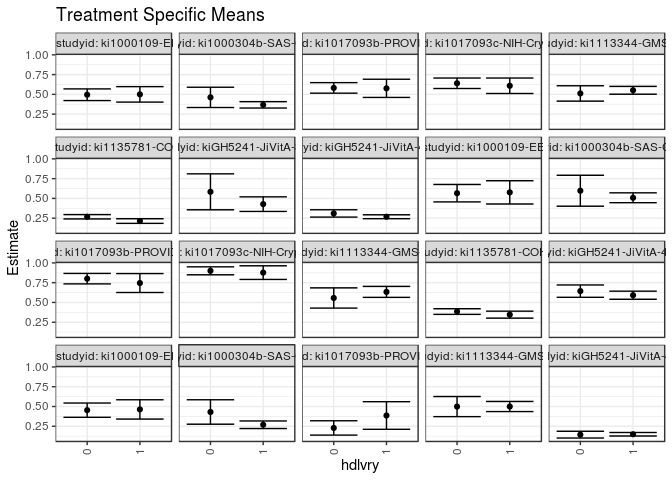

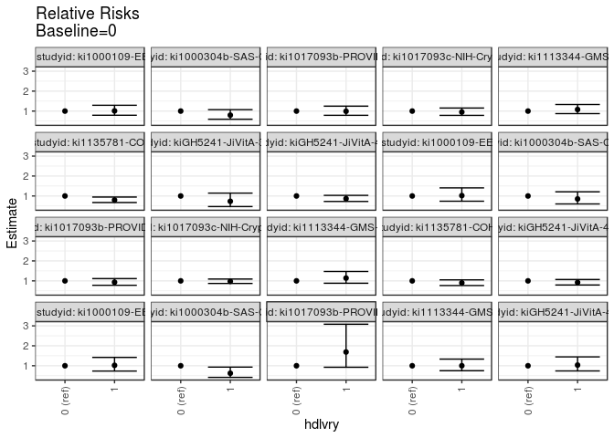

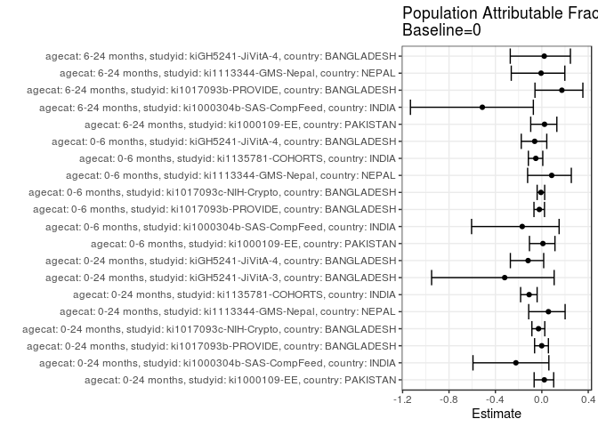

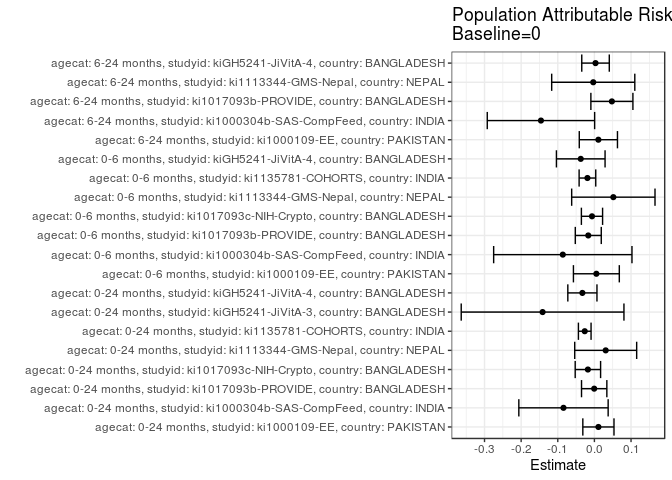

## Results Table

### Parameter: TSM

| agecat | studyid | country | intervention_level | baseline_level | estimate | ci_lower | ci_upper |
| --- | --- | --- | --- | --- | --- | --- | --- |
| 0-24 months | ki1000109-EE | PAKISTAN | 0 | NA | 0.4952886 | 0.4215018 | 0.5690755 |
| 0-24 months | ki1000109-EE | PAKISTAN | 1 | NA | 0.5001319 | 0.4023508 | 0.5979131 |
| 0-24 months | ki1000304b-SAS-CompFeed | INDIA | 0 | NA | 0.4621754 | 0.3339315 | 0.5904193 |
| 0-24 months | ki1000304b-SAS-CompFeed | INDIA | 1 | NA | 0.3675523 | 0.3274268 | 0.4076779 |
| 0-24 months | ki1017093b-PROVIDE | BANGLADESH | 0 | NA | 0.5817668 | 0.5152584 | 0.6482752 |
| 0-24 months | ki1017093b-PROVIDE | BANGLADESH | 1 | NA | 0.5761490 | 0.4611040 | 0.6911939 |
| 0-24 months | ki1017093c-NIH-Crypto | BANGLADESH | 0 | NA | 0.6403525 | 0.5743190 | 0.7063861 |
| 0-24 months | ki1017093c-NIH-Crypto | BANGLADESH | 1 | NA | 0.6086858 | 0.5109955 | 0.7063760 |
| 0-24 months | ki1113344-GMS-Nepal | NEPAL | 0 | NA | 0.5115508 | 0.4145120 | 0.6085895 |
| 0-24 months | ki1113344-GMS-Nepal | NEPAL | 1 | NA | 0.5515135 | 0.5021929 | 0.6008341 |
| 0-24 months | ki1135781-COHORTS | INDIA | 0 | NA | 0.2677537 | 0.2402914 | 0.2952161 |
| 0-24 months | ki1135781-COHORTS | INDIA | 1 | NA | 0.2135862 | 0.1843568 | 0.2428157 |
| 0-24 months | kiGH5241-JiVitA-3 | BANGLADESH | 0 | NA | 0.5833333 | 0.3560459 | 0.8106207 |
| 0-24 months | kiGH5241-JiVitA-3 | BANGLADESH | 1 | NA | 0.4273504 | 0.3351375 | 0.5195633 |
| 0-24 months | kiGH5241-JiVitA-4 | BANGLADESH | 0 | NA | 0.3099187 | 0.2634791 | 0.3563583 |
| 0-24 months | kiGH5241-JiVitA-4 | BANGLADESH | 1 | NA | 0.2679788 | 0.2434086 | 0.2925490 |
| 0-6 months | ki1000109-EE | PAKISTAN | 0 | NA | 0.5660610 | 0.4559354 | 0.6761866 |
| 0-6 months | ki1000109-EE | PAKISTAN | 1 | NA | 0.5764151 | 0.4293205 | 0.7235097 |
| 0-6 months | ki1000304b-SAS-CompFeed | INDIA | 0 | NA | 0.5970489 | 0.4014158 | 0.7926821 |
| 0-6 months | ki1000304b-SAS-CompFeed | INDIA | 1 | NA | 0.5081582 | 0.4457217 | 0.5705947 |
| 0-6 months | ki1017093b-PROVIDE | BANGLADESH | 0 | NA | 0.8005083 | 0.7344024 | 0.8666141 |
| 0-6 months | ki1017093b-PROVIDE | BANGLADESH | 1 | NA | 0.7453432 | 0.6256460 | 0.8650405 |
| 0-6 months | ki1017093c-NIH-Crypto | BANGLADESH | 0 | NA | 0.9000000 | 0.8497073 | 0.9502927 |
| 0-6 months | ki1017093c-NIH-Crypto | BANGLADESH | 1 | NA | 0.8771930 | 0.7908916 | 0.9634944 |
| 0-6 months | ki1113344-GMS-Nepal | NEPAL | 0 | NA | 0.5564635 | 0.4285347 | 0.6843923 |
| 0-6 months | ki1113344-GMS-Nepal | NEPAL | 1 | NA | 0.6334094 | 0.5640755 | 0.7027434 |
| 0-6 months | ki1135781-COHORTS | INDIA | 0 | NA | 0.3848729 | 0.3491490 | 0.4205969 |
| 0-6 months | ki1135781-COHORTS | INDIA | 1 | NA | 0.3455311 | 0.3015434 | 0.3895188 |
| 0-6 months | kiGH5241-JiVitA-4 | BANGLADESH | 0 | NA | 0.6432318 | 0.5652176 | 0.7212459 |
| 0-6 months | kiGH5241-JiVitA-4 | BANGLADESH | 1 | NA | 0.5914085 | 0.5402236 | 0.6425934 |
| 6-24 months | ki1000109-EE | PAKISTAN | 0 | NA | 0.4534505 | 0.3634692 | 0.5434319 |
| 6-24 months | ki1000109-EE | PAKISTAN | 1 | NA | 0.4630118 | 0.3408836 | 0.5851401 |
| 6-24 months | ki1000304b-SAS-CompFeed | INDIA | 0 | NA | 0.4305544 | 0.2760032 | 0.5851055 |
| 6-24 months | ki1000304b-SAS-CompFeed | INDIA | 1 | NA | 0.2690006 | 0.2212729 | 0.3167283 |
| 6-24 months | ki1017093b-PROVIDE | BANGLADESH | 0 | NA | 0.2286735 | 0.1382162 | 0.3191307 |
| 6-24 months | ki1017093b-PROVIDE | BANGLADESH | 1 | NA | 0.3861756 | 0.2116572 | 0.5606940 |
| 6-24 months | ki1113344-GMS-Nepal | NEPAL | 0 | NA | 0.4988321 | 0.3717644 | 0.6258998 |
| 6-24 months | ki1113344-GMS-Nepal | NEPAL | 1 | NA | 0.4996117 | 0.4356694 | 0.5635541 |
| 6-24 months | kiGH5241-JiVitA-4 | BANGLADESH | 0 | NA | 0.1437206 | 0.1007528 | 0.1866884 |
| 6-24 months | kiGH5241-JiVitA-4 | BANGLADESH | 1 | NA | 0.1487164 | 0.1266214 | 0.1708114 |

### Parameter: E(Y)

| agecat | studyid | country | intervention_level | baseline_level | estimate | ci_lower | ci_upper |
| --- | --- | --- | --- | --- | --- | --- | --- |
| 0-24 months | ki1000109-EE | PAKISTAN | NA | NA | 0.5062112 | 0.4470670 | 0.5653554 |
| 0-24 months | ki1000304b-SAS-CompFeed | INDIA | NA | NA | 0.3777778 | 0.3394240 | 0.4161316 |
| 0-24 months | ki1017093b-PROVIDE | BANGLADESH | NA | NA | 0.5811688 | 0.5245443 | 0.6377934 |
| 0-24 months | ki1017093c-NIH-Crypto | BANGLADESH | NA | NA | 0.6225806 | 0.5684562 | 0.6767051 |
| 0-24 months | ki1113344-GMS-Nepal | NEPAL | NA | NA | 0.5423729 | 0.4984575 | 0.5862883 |
| 0-24 months | ki1135781-COHORTS | INDIA | NA | NA | 0.2413610 | 0.2219406 | 0.2607813 |
| 0-24 months | kiGH5241-JiVitA-3 | BANGLADESH | NA | NA | 0.4418605 | 0.3551361 | 0.5285849 |
| 0-24 months | kiGH5241-JiVitA-4 | BANGLADESH | NA | NA | 0.2771220 | 0.2556194 | 0.2986246 |
| 0-6 months | ki1000109-EE | PAKISTAN | NA | NA | 0.5714286 | 0.4842880 | 0.6585691 |
| 0-6 months | ki1000304b-SAS-CompFeed | INDIA | NA | NA | 0.5107914 | 0.4514901 | 0.5700927 |
| 0-6 months | ki1017093b-PROVIDE | BANGLADESH | NA | NA | 0.7837838 | 0.7252863 | 0.8422812 |
| 0-6 months | ki1017093c-NIH-Crypto | BANGLADESH | NA | NA | 0.8934010 | 0.8497799 | 0.9370221 |
| 0-6 months | ki1113344-GMS-Nepal | NEPAL | NA | NA | 0.6081633 | 0.5464350 | 0.6698915 |
| 0-6 months | ki1135781-COHORTS | INDIA | NA | NA | 0.3658340 | 0.3390250 | 0.3926430 |
| 0-6 months | kiGH5241-JiVitA-4 | BANGLADESH | NA | NA | 0.6059406 | 0.5632798 | 0.6486014 |
| 6-24 months | ki1000109-EE | PAKISTAN | NA | NA | 0.4642857 | 0.3910729 | 0.5374985 |
| 6-24 months | ki1000304b-SAS-CompFeed | INDIA | NA | NA | 0.2846348 | 0.2390527 | 0.3302168 |
| 6-24 months | ki1017093b-PROVIDE | BANGLADESH | NA | NA | 0.2764228 | 0.1950773 | 0.3577682 |
| 6-24 months | ki1113344-GMS-Nepal | NEPAL | NA | NA | 0.4956522 | 0.4389718 | 0.5523326 |
| 6-24 months | kiGH5241-JiVitA-4 | BANGLADESH | NA | NA | 0.1467818 | 0.1275683 | 0.1659953 |

### Parameter: RR

| agecat | studyid | country | intervention_level | baseline_level | estimate | ci_lower | ci_upper |
| --- | --- | --- | --- | --- | --- | --- | --- |
| 0-24 months | ki1000109-EE | PAKISTAN | 0 | 0 | 1.0000000 | 1.0000000 | 1.0000000 |
| 0-24 months | ki1000109-EE | PAKISTAN | 1 | 0 | 1.0097788 | 0.7896250 | 1.2913131 |
| 0-24 months | ki1000304b-SAS-CompFeed | INDIA | 0 | 0 | 1.0000000 | 1.0000000 | 1.0000000 |
| 0-24 months | ki1000304b-SAS-CompFeed | INDIA | 1 | 0 | 0.7952658 | 0.5904416 | 1.0711437 |
| 0-24 months | ki1017093b-PROVIDE | BANGLADESH | 0 | 0 | 1.0000000 | 1.0000000 | 1.0000000 |
| 0-24 months | ki1017093b-PROVIDE | BANGLADESH | 1 | 0 | 0.9903435 | 0.7865146 | 1.2469957 |
| 0-24 months | ki1017093c-NIH-Crypto | BANGLADESH | 0 | 0 | 1.0000000 | 1.0000000 | 1.0000000 |
| 0-24 months | ki1017093c-NIH-Crypto | BANGLADESH | 1 | 0 | 0.9505479 | 0.7846865 | 1.1514679 |
| 0-24 months | ki1113344-GMS-Nepal | NEPAL | 0 | 0 | 1.0000000 | 1.0000000 | 1.0000000 |
| 0-24 months | ki1113344-GMS-Nepal | NEPAL | 1 | 0 | 1.0781207 | 0.8738714 | 1.3301089 |
| 0-24 months | ki1135781-COHORTS | INDIA | 0 | 0 | 1.0000000 | 1.0000000 | 1.0000000 |
| 0-24 months | ki1135781-COHORTS | INDIA | 1 | 0 | 0.7976964 | 0.6721761 | 0.9466562 |
| 0-24 months | kiGH5241-JiVitA-3 | BANGLADESH | 0 | 0 | 1.0000000 | 1.0000000 | 1.0000000 |
| 0-24 months | kiGH5241-JiVitA-3 | BANGLADESH | 1 | 0 | 0.7326007 | 0.4692527 | 1.1437415 |
| 0-24 months | kiGH5241-JiVitA-4 | BANGLADESH | 0 | 0 | 1.0000000 | 1.0000000 | 1.0000000 |
| 0-24 months | kiGH5241-JiVitA-4 | BANGLADESH | 1 | 0 | 0.8646744 | 0.7253045 | 1.0308248 |
| 0-6 months | ki1000109-EE | PAKISTAN | 0 | 0 | 1.0000000 | 1.0000000 | 1.0000000 |
| 0-6 months | ki1000109-EE | PAKISTAN | 1 | 0 | 1.0182914 | 0.7375175 | 1.4059563 |
| 0-6 months | ki1000304b-SAS-CompFeed | INDIA | 0 | 0 | 1.0000000 | 1.0000000 | 1.0000000 |
| 0-6 months | ki1000304b-SAS-CompFeed | INDIA | 1 | 0 | 0.8511165 | 0.5995000 | 1.2083391 |
| 0-6 months | ki1017093b-PROVIDE | BANGLADESH | 0 | 0 | 1.0000000 | 1.0000000 | 1.0000000 |
| 0-6 months | ki1017093b-PROVIDE | BANGLADESH | 1 | 0 | 0.9310875 | 0.7788722 | 1.1130503 |
| 0-6 months | ki1017093c-NIH-Crypto | BANGLADESH | 0 | 0 | 1.0000000 | 1.0000000 | 1.0000000 |
| 0-6 months | ki1017093c-NIH-Crypto | BANGLADESH | 1 | 0 | 0.9746589 | 0.8703902 | 1.0914184 |
| 0-6 months | ki1113344-GMS-Nepal | NEPAL | 0 | 0 | 1.0000000 | 1.0000000 | 1.0000000 |
| 0-6 months | ki1113344-GMS-Nepal | NEPAL | 1 | 0 | 1.1382767 | 0.8809915 | 1.4706995 |
| 0-6 months | ki1135781-COHORTS | INDIA | 0 | 0 | 1.0000000 | 1.0000000 | 1.0000000 |
| 0-6 months | ki1135781-COHORTS | INDIA | 1 | 0 | 0.8977797 | 0.7668193 | 1.0511059 |
| 0-6 months | kiGH5241-JiVitA-4 | BANGLADESH | 0 | 0 | 1.0000000 | 1.0000000 | 1.0000000 |
| 0-6 months | kiGH5241-JiVitA-4 | BANGLADESH | 1 | 0 | 0.9194329 | 0.7920393 | 1.0673168 |
| 6-24 months | ki1000109-EE | PAKISTAN | 0 | 0 | 1.0000000 | 1.0000000 | 1.0000000 |
| 6-24 months | ki1000109-EE | PAKISTAN | 1 | 0 | 1.0210856 | 0.7343703 | 1.4197413 |
| 6-24 months | ki1000304b-SAS-CompFeed | INDIA | 0 | 0 | 1.0000000 | 1.0000000 | 1.0000000 |
| 6-24 months | ki1000304b-SAS-CompFeed | INDIA | 1 | 0 | 0.6247774 | 0.4181383 | 0.9335352 |
| 6-24 months | ki1017093b-PROVIDE | BANGLADESH | 0 | 0 | 1.0000000 | 1.0000000 | 1.0000000 |
| 6-24 months | ki1017093b-PROVIDE | BANGLADESH | 1 | 0 | 1.6887643 | 0.9254600 | 3.0816294 |
| 6-24 months | ki1113344-GMS-Nepal | NEPAL | 0 | 0 | 1.0000000 | 1.0000000 | 1.0000000 |
| 6-24 months | ki1113344-GMS-Nepal | NEPAL | 1 | 0 | 1.0015629 | 0.7519772 | 1.3339874 |
| 6-24 months | kiGH5241-JiVitA-4 | BANGLADESH | 0 | 0 | 1.0000000 | 1.0000000 | 1.0000000 |
| 6-24 months | kiGH5241-JiVitA-4 | BANGLADESH | 1 | 0 | 1.0347603 | 0.7408862 | 1.4452002 |

### Parameter: PAR

| agecat | studyid | country | intervention_level | baseline_level | estimate | ci_lower | ci_upper |
| --- | --- | --- | --- | --- | --- | --- | --- |
| 0-24 months | ki1000109-EE | PAKISTAN | 0 | NA | 0.0109225 | -0.0316058 | 0.0534509 |
| 0-24 months | ki1000304b-SAS-CompFeed | INDIA | 0 | NA | -0.0843977 | -0.2063135 | 0.0375182 |
| 0-24 months | ki1017093b-PROVIDE | BANGLADESH | 0 | NA | -0.0005980 | -0.0351665 | 0.0339706 |
| 0-24 months | ki1017093c-NIH-Crypto | BANGLADESH | 0 | NA | -0.0177719 | -0.0524388 | 0.0168950 |
| 0-24 months | ki1113344-GMS-Nepal | NEPAL | 0 | NA | 0.0308221 | -0.0537378 | 0.1153820 |
| 0-24 months | ki1135781-COHORTS | INDIA | 0 | NA | -0.0263928 | -0.0436589 | -0.0091266 |
| 0-24 months | kiGH5241-JiVitA-3 | BANGLADESH | 0 | NA | -0.1414729 | -0.3635901 | 0.0806444 |
| 0-24 months | kiGH5241-JiVitA-4 | BANGLADESH | 0 | NA | -0.0327967 | -0.0725626 | 0.0069691 |
| 0-6 months | ki1000109-EE | PAKISTAN | 0 | NA | 0.0053675 | -0.0572562 | 0.0679913 |
| 0-6 months | ki1000304b-SAS-CompFeed | INDIA | 0 | NA | -0.0862576 | -0.2750615 | 0.1025464 |
| 0-6 months | ki1017093b-PROVIDE | BANGLADESH | 0 | NA | -0.0167245 | -0.0521785 | 0.0187295 |
| 0-6 months | ki1017093c-NIH-Crypto | BANGLADESH | 0 | NA | -0.0065990 | -0.0355389 | 0.0223409 |
| 0-6 months | ki1113344-GMS-Nepal | NEPAL | 0 | NA | 0.0516997 | -0.0620448 | 0.1654443 |
| 0-6 months | ki1135781-COHORTS | INDIA | 0 | NA | -0.0190389 | -0.0417405 | 0.0036626 |
| 0-6 months | kiGH5241-JiVitA-4 | BANGLADESH | 0 | NA | -0.0372912 | -0.1036795 | 0.0290971 |
| 6-24 months | ki1000109-EE | PAKISTAN | 0 | NA | 0.0108352 | -0.0412918 | 0.0629622 |
| 6-24 months | ki1000304b-SAS-CompFeed | INDIA | 0 | NA | -0.1459196 | -0.2924883 | 0.0006491 |
| 6-24 months | ki1017093b-PROVIDE | BANGLADESH | 0 | NA | 0.0477493 | -0.0096215 | 0.1051201 |
| 6-24 months | ki1113344-GMS-Nepal | NEPAL | 0 | NA | -0.0031799 | -0.1166318 | 0.1102719 |
| 6-24 months | kiGH5241-JiVitA-4 | BANGLADESH | 0 | NA | 0.0030612 | -0.0345256 | 0.0406480 |

### Parameter: PAF

| agecat | studyid | country | intervention_level | baseline_level | estimate | ci_lower | ci_upper |
| --- | --- | --- | --- | --- | --- | --- | --- |
| 0-24 months | ki1000109-EE | PAKISTAN | 0 | NA | 0.0215771 | -0.0662648 | 0.1021822 |
| 0-24 months | ki1000304b-SAS-CompFeed | INDIA | 0 | NA | -0.2234056 | -0.5933752 | 0.0606599 |
| 0-24 months | ki1017093b-PROVIDE | BANGLADESH | 0 | NA | -0.0010289 | -0.0623122 | 0.0567190 |
| 0-24 months | ki1017093c-NIH-Crypto | BANGLADESH | 0 | NA | -0.0285455 | -0.0856612 | 0.0255653 |
| 0-24 months | ki1113344-GMS-Nepal | NEPAL | 0 | NA | 0.0568282 | -0.1130319 | 0.2007659 |
| 0-24 months | ki1135781-COHORTS | INDIA | 0 | NA | -0.1093498 | -0.1827144 | -0.0405360 |
| 0-24 months | kiGH5241-JiVitA-3 | BANGLADESH | 0 | NA | -0.3201754 | -0.9499839 | 0.1062166 |
| 0-24 months | kiGH5241-JiVitA-4 | BANGLADESH | 0 | NA | -0.1183477 | -0.2711004 | 0.0160482 |
| 0-6 months | ki1000109-EE | PAKISTAN | 0 | NA | 0.0093932 | -0.1065905 | 0.1132205 |
| 0-6 months | ki1000304b-SAS-CompFeed | INDIA | 0 | NA | -0.1688704 | -0.6054062 | 0.1489642 |
| 0-6 months | ki1017093b-PROVIDE | BANGLADESH | 0 | NA | -0.0213381 | -0.0677422 | 0.0230493 |
| 0-6 months | ki1017093c-NIH-Crypto | BANGLADESH | 0 | NA | -0.0073864 | -0.0403389 | 0.0245224 |
| 0-6 months | ki1113344-GMS-Nepal | NEPAL | 0 | NA | 0.0850096 | -0.1224626 | 0.2541334 |
| 0-6 months | ki1135781-COHORTS | INDIA | 0 | NA | -0.0520425 | -0.1159477 | 0.0082032 |
| 0-6 months | kiGH5241-JiVitA-4 | BANGLADESH | 0 | NA | -0.0615426 | -0.1771732 | 0.0427299 |
| 6-24 months | ki1000109-EE | PAKISTAN | 0 | NA | 0.0233373 | -0.0957222 | 0.1294600 |
| 6-24 months | ki1000304b-SAS-CompFeed | INDIA | 0 | NA | -0.5126556 | -1.1324569 | -0.0730003 |
| 6-24 months | ki1017093b-PROVIDE | BANGLADESH | 0 | NA | 0.1727401 | -0.0590596 | 0.3538050 |
| 6-24 months | ki1113344-GMS-Nepal | NEPAL | 0 | NA | -0.0064157 | -0.2634268 | 0.1983133 |
| 6-24 months | kiGH5241-JiVitA-4 | BANGLADESH | 0 | NA | 0.0208552 | -0.2719994 | 0.2462854 |